# Forecasting Section 6.7

Seema Rani Kanuri

May 3, 2017

# Question 1:

Show that a 3×53×5 MA is equivalent to a 7-term weighted moving average with weights of 0.067, 0.133, 0.200, 0.200, 0.200, 0.133, and 0.067.

```r
library(forecast)
library(fpp)
library(TTR)
values=c(0.067, 0.133, 0.200, 0.200, 0.200, 0.133,0.067)
moveavg = ma(values, order = 5)
weightedmoveavg=WMA(values,n = 5)
sum(na.omit(moveavg))
```

```
## [1] 0.4932
```

```r
sum(na.omit(weightedmoveavg))
```

```
## [1] 0.4932
```

# Question 2:

The data below represent the monthly sales (in thousands) of product A for a plastics manufacturer for years 1 through 5 (data set plastics).

### a. Plot the time series of sales of product A. Can you identify seasonal fluctuations and/or a trend?

```r
library(fma)
library(fpp)
```

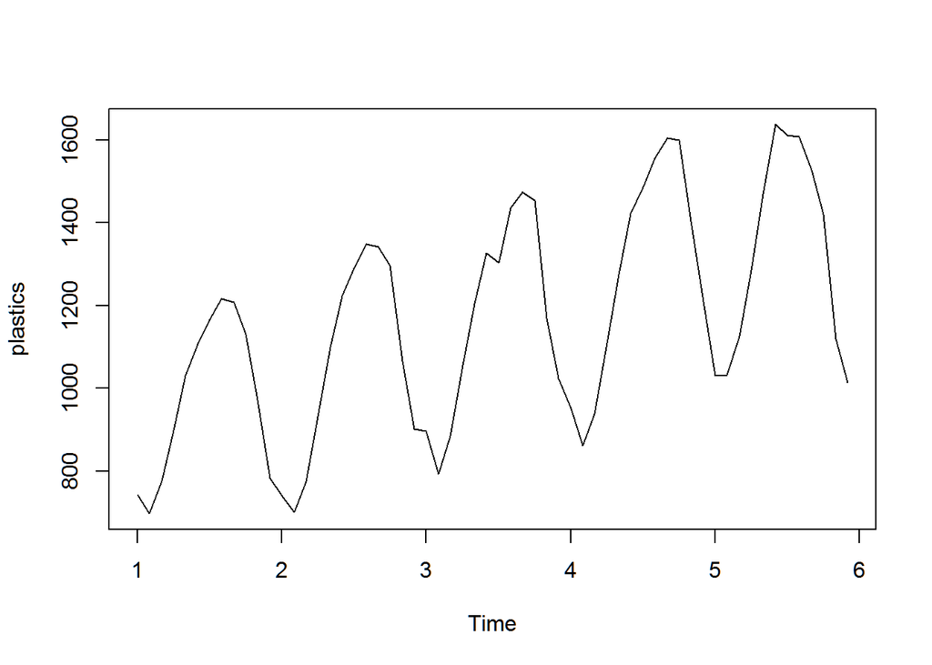

```r
ts <- plastics
plot(plastics)
```

There are seasonal fluctuation with sales peaking in summer and reaching troughs in winter. There is a positive trend throughout the series.

### b. Use a classical multiplicative decomposition to calculate the trend-cycle and seasonal indices.

```r
fit <- decompose(ts, type="multiplicative")

trend_indices <- fit$trend
seasonal_indices <- fit$seasonal
```

### c. Do the results support the graphical interpretation from part (a)?

The graph indicates that the summer months should have higher seasonal indices than the winter months and this is indeed the case.

### d. Compute and plot the seasonally adjusted data.

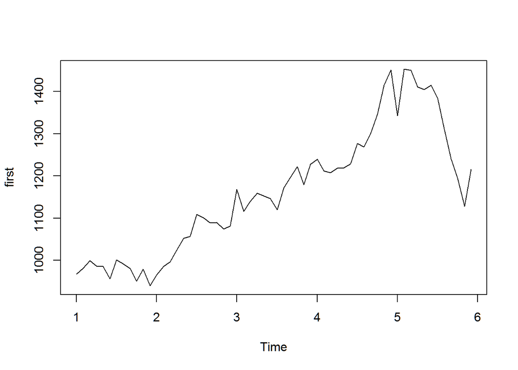

```r
first <- seasadj(fit)
plot(first)
```

## e. Change one observation to be an outlier (e.g., add 500 to one observation), and recompute the seasonally adjusted data. What is the effect of the outlier?

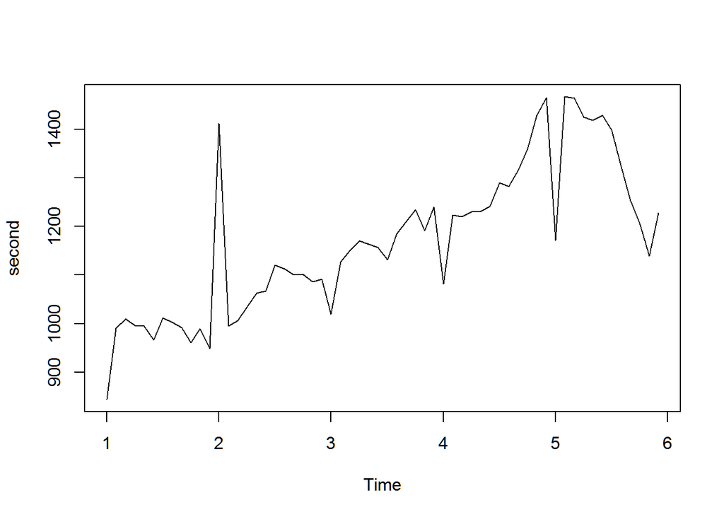

```r
ts2 <- ts
ts2[13] = ts2[13] + 500
fit2 <- decompose(ts2, type="multiplicative")
second <- seasadj(fit2)
plot(second)
```

The outlier causes a spike in the graph at the month it was inserted.

### f. Does it make any difference if the outlier is near the end rather than in the middle of the time series?

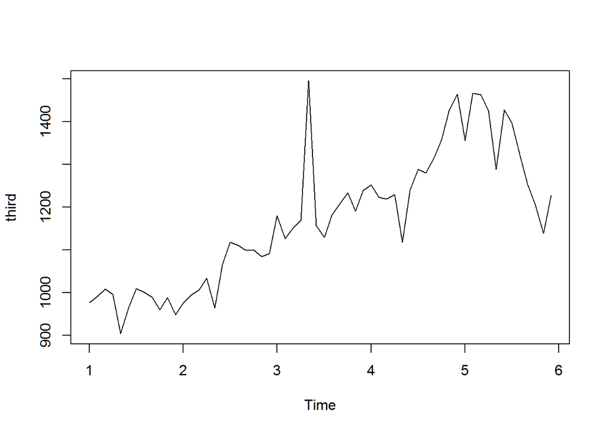

```r
ts3 <- ts
ts3[29] = ts3[29] + 500

fit3 <- decompose(ts3, type='multiplicative')

third <- seasadj(fit3)

ts4 <- ts
ts4[51] = ts4[51] + 500

fit4 <- decompose(ts4, type='multiplicative')

fourth <- seasadj(fit4)

plot(third)
```

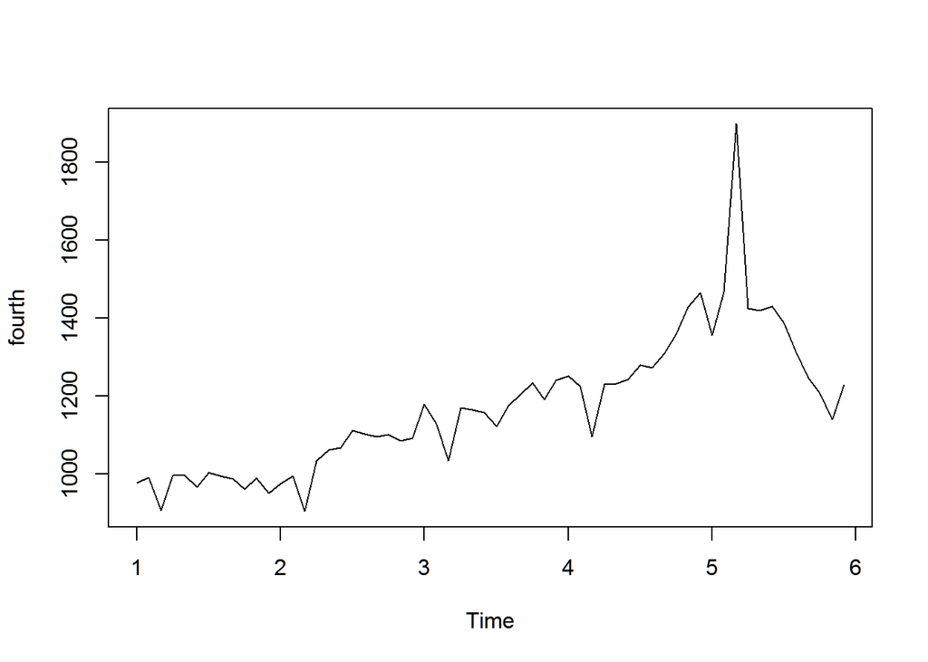

```r
plot(fourth)
```

### g. Use a random walk with drift to produce forecasts of the seasonally adjusted data.

```r
fit5 <- rwf(first, drift=TRUE)
```

### h. Reseasonalize the results to give forecasts on the original scale.

```r
fit5 <- stl(ts, t.window=15, s.window="periodic", robust=TRUE)
fit6 <- forecast(fit5, method="naive")
```

# Question 3: